# Risk Factor Analysis

## Outcome Variable

**Outcome Variable:** y_rate_haz

## Predictor Variables

**Intervention Variable:** parity

**Adjustment Set:**

- arm
- W_mage
- meducyrs
- feducyrs
- hhwealth_quart
- W_mhtcm
- vagbrth
- W_nrooms
- impsan
- delta_W_mage
- delta_meducyrs
- delta_feducyrs
- delta_hhwealth_quart
- delta_W_mhtcm
- delta_vagbrth
- delta_W_nrooms
- delta_impsan

## Stratifying Variables

The analysis was stratified on these variable(s):

- agecat
- studyid
- country

## Data Summary

| agecat | studyid | country | parity | n_cell | n |
| --- | --- | --- | --- | --- | --- |
| 0-3 months | ki1017093b-PROVIDE | BANGLADESH | 1 | 240 | 634 |
| 0-3 months | ki1017093b-PROVIDE | BANGLADESH | 2 | 225 | 634 |
| 0-3 months | ki1017093b-PROVIDE | BANGLADESH | 3+ | 169 | 634 |
| 0-3 months | kiGH5241-JiVitA-3 | BANGLADESH | 1 | 6375 | 20028 |
| 0-3 months | kiGH5241-JiVitA-3 | BANGLADESH | 2 | 6945 | 20028 |
| 0-3 months | kiGH5241-JiVitA-3 | BANGLADESH | 3+ | 6708 | 20028 |
| 0-3 months | ki1101329-Keneba | GAMBIA | 1 | 130 | 1145 |
| 0-3 months | ki1101329-Keneba | GAMBIA | 2 | 113 | 1145 |
| 0-3 months | ki1101329-Keneba | GAMBIA | 3+ | 902 | 1145 |
| 0-3 months | ki1135781-COHORTS | GUATEMALA | 1 | 93 | 728 |
| 0-3 months | ki1135781-COHORTS | GUATEMALA | 2 | 111 | 728 |
| 0-3 months | ki1135781-COHORTS | GUATEMALA | 3+ | 524 | 728 |
| 0-3 months | ki1000304b-SAS-CompFeed | INDIA | 1 | 313 | 1168 |
| 0-3 months | ki1000304b-SAS-CompFeed | INDIA | 2 | 280 | 1168 |
| 0-3 months | ki1000304b-SAS-CompFeed | INDIA | 3+ | 575 | 1168 |
| 0-3 months | ki1135781-COHORTS | INDIA | 1 | 671 | 4021 |
| 0-3 months | ki1135781-COHORTS | INDIA | 2 | 1015 | 4021 |
| 0-3 months | ki1135781-COHORTS | INDIA | 3+ | 2335 | 4021 |
| 0-3 months | ki1126311-ZVITAMBO | ZIMBABWE | 1 | 3052 | 7863 |
| 0-3 months | ki1126311-ZVITAMBO | ZIMBABWE | 2 | 2438 | 7863 |
| 0-3 months | ki1126311-ZVITAMBO | ZIMBABWE | 3+ | 2373 | 7863 |
| 3-6 months | ki1017093b-PROVIDE | BANGLADESH | 1 | 206 | 574 |
| 3-6 months | ki1017093b-PROVIDE | BANGLADESH | 2 | 211 | 574 |
| 3-6 months | ki1017093b-PROVIDE | BANGLADESH | 3+ | 157 | 574 |
| 3-6 months | kiGH5241-JiVitA-3 | BANGLADESH | 1 | 4401 | 12573 |
| 3-6 months | kiGH5241-JiVitA-3 | BANGLADESH | 2 | 4359 | 12573 |
| 3-6 months | kiGH5241-JiVitA-3 | BANGLADESH | 3+ | 3813 | 12573 |
| 3-6 months | ki1101329-Keneba | GAMBIA | 1 | 146 | 1130 |
| 3-6 months | ki1101329-Keneba | GAMBIA | 2 | 107 | 1130 |
| 3-6 months | ki1101329-Keneba | GAMBIA | 3+ | 877 | 1130 |

[output cut: 77 more lines]

The following strata were considered:

- agecat: 0-3 months, studyid: ki1000304b-SAS-CompFeed, country: INDIA
- agecat: 0-3 months, studyid: ki1017093b-PROVIDE, country: BANGLADESH
- agecat: 0-3 months, studyid: ki1101329-Keneba, country: GAMBIA
- agecat: 0-3 months, studyid: ki1126311-ZVITAMBO, country: ZIMBABWE
- agecat: 0-3 months, studyid: ki1135781-COHORTS, country: GUATEMALA
- agecat: 0-3 months, studyid: ki1135781-COHORTS, country: INDIA
- agecat: 0-3 months, studyid: kiGH5241-JiVitA-3, country: BANGLADESH
- agecat: 12-24 months, studyid: ki1017093b-PROVIDE, country: BANGLADESH
- agecat: 12-24 months, studyid: ki1066203-TanzaniaChild2, country: TANZANIA, UNITED REPUBLIC OF
- agecat: 12-24 months, studyid: ki1101329-Keneba, country: GAMBIA
- agecat: 12-24 months, studyid: ki1113344-GMS-Nepal, country: NEPAL
- agecat: 12-24 months, studyid: ki1126311-ZVITAMBO, country: ZIMBABWE
- agecat: 12-24 months, studyid: ki1135781-COHORTS, country: GUATEMALA
- agecat: 12-24 months, studyid: ki1135781-COHORTS, country: INDIA
- agecat: 12-24 months, studyid: ki1135781-COHORTS, country: PHILIPPINES
- agecat: 12-24 months, studyid: kiGH5241-JiVitA-3, country: BANGLADESH
- agecat: 3-6 months, studyid: ki1000304b-SAS-CompFeed, country: INDIA
- agecat: 3-6 months, studyid: ki1017093b-PROVIDE, country: BANGLADESH
- agecat: 3-6 months, studyid: ki1066203-TanzaniaChild2, country: TANZANIA, UNITED REPUBLIC OF
- agecat: 3-6 months, studyid: ki1101329-Keneba, country: GAMBIA
- agecat: 3-6 months, studyid: ki1113344-GMS-Nepal, country: NEPAL
- agecat: 3-6 months, studyid: ki1126311-ZVITAMBO, country: ZIMBABWE
- agecat: 3-6 months, studyid: ki1135781-COHORTS, country: GUATEMALA
- agecat: 3-6 months, studyid: ki1135781-COHORTS, country: INDIA
- agecat: 3-6 months, studyid: kiGH5241-JiVitA-3, country: BANGLADESH
- agecat: 6-12 months, studyid: ki1000304b-SAS-CompFeed, country: INDIA
- agecat: 6-12 months, studyid: ki1000304b-SAS-FoodSuppl, country: INDIA
- agecat: 6-12 months, studyid: ki1017093b-PROVIDE, country: BANGLADESH
- agecat: 6-12 months, studyid: ki1066203-TanzaniaChild2, country: TANZANIA, UNITED REPUBLIC OF
- agecat: 6-12 months, studyid: ki1101329-Keneba, country: GAMBIA
- agecat: 6-12 months, studyid: ki1113344-GMS-Nepal, country: NEPAL
- agecat: 6-12 months, studyid: ki1126311-ZVITAMBO, country: ZIMBABWE
- agecat: 6-12 months, studyid: ki1135781-COHORTS, country: GUATEMALA
- agecat: 6-12 months, studyid: ki1135781-COHORTS, country: INDIA
- agecat: 6-12 months, studyid: ki1135781-COHORTS, country: PHILIPPINES
- agecat: 6-12 months, studyid: kiGH5241-JiVitA-3, country: BANGLADESH

### Dropped Strata

Some strata were dropped due to rare outcomes:

- agecat: 12-24 months, studyid: ki1066203-TanzaniaChild2, country: TANZANIA, UNITED REPUBLIC OF

## Methods Detail

We’re interested in the causal parameters $E[Y_a]$ for all values of $a \in \mathcal{A}$. These parameters represent the mean outcome if, possibly contrary to fact, we intervened to set all units to have $A=a$. Under the randomization and positivity assumptions, these are identified by the statistical parameters $\psi_a=E_W[E_{Y|A,W}(Y|A=a,W)]$. In addition, we’re interested in the mean of $Y$, $E[Y]$ under no intervention (the observed mean). We will estimate these parameters by using SuperLearner to fit the relevant likelihood factors – $E_{Y|A,W}(Y|A=a,W)$ and $p(A=a|W)$, and then updating our likelihood fit using a joint TMLE.

For unadjusted analyses ($W=\{\}$), initial likelihoods were estimated using Lrnr_glm to estimate the simple $E(Y|A)$ and Lrnr_mean to estimate $p(A)$. For adjusted analyses, a small library containing Lrnr_glmnet, Lrnr_xgboost, and Lrnr_mean was used.

Having estimated these parameters, we will then use the delta method to estimate relative risks and attributable risks relative to a prespecified baseline level of $A$.

# Results Detail

## Results Plots

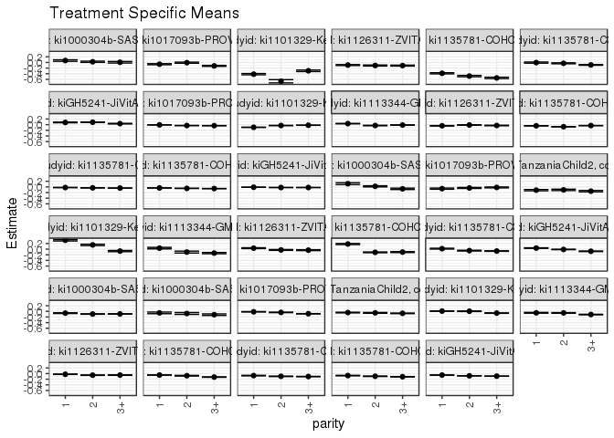

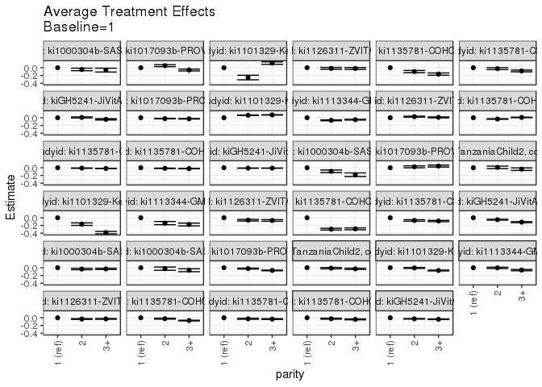

## Results Table

### Parameter: TSM

| agecat | studyid | country | intervention_level | baseline_level | estimate | ci_lower | ci_upper |
| --- | --- | --- | --- | --- | --- | --- | --- |
| 0-3 months | ki1000304b-SAS-CompFeed | INDIA | 1 | NA | 0.0680770 | 0.0411543 | 0.0949997 |
| 0-3 months | ki1000304b-SAS-CompFeed | INDIA | 2 | NA | 0.0235206 | 0.0020103 | 0.0450310 |
| 0-3 months | ki1000304b-SAS-CompFeed | INDIA | 3+ | NA | 0.0061336 | -0.0222608 | 0.0345279 |
| 0-3 months | ki1017093b-PROVIDE | BANGLADESH | 1 | NA | -0.0625591 | -0.0810879 | -0.0440303 |
| 0-3 months | ki1017093b-PROVIDE | BANGLADESH | 2 | NA | -0.0088683 | -0.0279430 | 0.0102064 |
| 0-3 months | ki1017093b-PROVIDE | BANGLADESH | 3+ | NA | -0.1218186 | -0.1387551 | -0.1048821 |
| 0-3 months | ki1101329-Keneba | GAMBIA | 1 | NA | -0.4155894 | -0.4378283 | -0.3933505 |
| 0-3 months | ki1101329-Keneba | GAMBIA | 2 | NA | -0.6680490 | -0.7256859 | -0.6104121 |
| 0-3 months | ki1101329-Keneba | GAMBIA | 3+ | NA | -0.2958479 | -0.3222867 | -0.2694091 |
| 0-3 months | ki1126311-ZVITAMBO | ZIMBABWE | 1 | NA | -0.0927508 | -0.1100854 | -0.0754162 |
| 0-3 months | ki1126311-ZVITAMBO | ZIMBABWE | 2 | NA | -0.1082826 | -0.1262028 | -0.0903625 |
| 0-3 months | ki1126311-ZVITAMBO | ZIMBABWE | 3+ | NA | -0.1120355 | -0.1290949 | -0.0949760 |
| 0-3 months | ki1135781-COHORTS | GUATEMALA | 1 | NA | -0.3843631 | -0.4046641 | -0.3640620 |
| 0-3 months | ki1135781-COHORTS | GUATEMALA | 2 | NA | -0.4838971 | -0.5073422 | -0.4604520 |
| 0-3 months | ki1135781-COHORTS | GUATEMALA | 3+ | NA | -0.5489855 | -0.5724283 | -0.5255427 |
| 0-3 months | ki1135781-COHORTS | INDIA | 1 | NA | -0.0058013 | -0.0253148 | 0.0137122 |
| 0-3 months | ki1135781-COHORTS | INDIA | 2 | NA | -0.0303158 | -0.0462636 | -0.0143679 |
| 0-3 months | ki1135781-COHORTS | INDIA | 3+ | NA | -0.0884967 | -0.1004684 | -0.0765250 |
| 0-3 months | kiGH5241-JiVitA-3 | BANGLADESH | 1 | NA | 0.0790024 | 0.0663168 | 0.0916881 |
| 0-3 months | kiGH5241-JiVitA-3 | BANGLADESH | 2 | NA | 0.0866916 | 0.0784796 | 0.0949035 |
| 0-3 months | kiGH5241-JiVitA-3 | BANGLADESH | 3+ | NA | 0.0369792 | 0.0270539 | 0.0469046 |
| 3-6 months | ki1000304b-SAS-CompFeed | INDIA | 1 | NA | 0.1123028 | 0.0786912 | 0.1459145 |
| 3-6 months | ki1000304b-SAS-CompFeed | INDIA | 2 | NA | 0.0202113 | 0.0008674 | 0.0395552 |
| 3-6 months | ki1000304b-SAS-CompFeed | INDIA | 3+ | NA | -0.0681892 | -0.0922761 | -0.0441024 |
| 3-6 months | ki1017093b-PROVIDE | BANGLADESH | 1 | NA | -0.0618238 | -0.0824714 | -0.0411762 |
| 3-6 months | ki1017093b-PROVIDE | BANGLADESH | 2 | NA | -0.0375115 | -0.0540476 | -0.0209753 |
| 3-6 months | ki1017093b-PROVIDE | BANGLADESH | 3+ | NA | -0.0183306 | -0.0341098 | -0.0025515 |
| 3-6 months | ki1066203-TanzaniaChild2 | TANZANIA, UNITED REPUBLIC OF | 1 | NA | -0.1155044 | -0.1381805 | -0.0928282 |
| 3-6 months | ki1066203-TanzaniaChild2 | TANZANIA, UNITED REPUBLIC OF | 2 | NA | -0.1058839 | -0.1306431 | -0.0811247 |
| 3-6 months | ki1066203-TanzaniaChild2 | TANZANIA, UNITED REPUBLIC OF | 3+ | NA | -0.1516010 | -0.1746076 | -0.1285943 |

[output cut: 75 more lines]

### Parameter: E(Y)

| agecat | studyid | country | intervention_level | baseline_level | estimate | ci_lower | ci_upper |
| --- | --- | --- | --- | --- | --- | --- | --- |
| 0-3 months | ki1000304b-SAS-CompFeed | INDIA | NA | NA | 0.0123467 | -0.0036133 | 0.0283068 |
| 0-3 months | ki1017093b-PROVIDE | BANGLADESH | NA | NA | -0.0413143 | -0.0594662 | -0.0231624 |
| 0-3 months | ki1101329-Keneba | GAMBIA | NA | NA | -0.2853220 | -0.3108085 | -0.2598355 |
| 0-3 months | ki1126311-ZVITAMBO | ZIMBABWE | NA | NA | -0.1428480 | -0.1532568 | -0.1324391 |
| 0-3 months | ki1135781-COHORTS | GUATEMALA | NA | NA | -0.5431999 | -0.5652020 | -0.5211979 |
| 0-3 months | ki1135781-COHORTS | INDIA | NA | NA | -0.0684794 | -0.0774008 | -0.0595580 |
| 0-3 months | kiGH5241-JiVitA-3 | BANGLADESH | NA | NA | 0.0705478 | 0.0655933 | 0.0755023 |
| 3-6 months | ki1000304b-SAS-CompFeed | INDIA | NA | NA | -0.0166348 | -0.0360336 | 0.0027639 |
| 3-6 months | ki1017093b-PROVIDE | BANGLADESH | NA | NA | -0.0272428 | -0.0436954 | -0.0107902 |
| 3-6 months | ki1066203-TanzaniaChild2 | TANZANIA, UNITED REPUBLIC OF | NA | NA | -0.0840487 | -0.1007413 | -0.0673560 |
| 3-6 months | ki1101329-Keneba | GAMBIA | NA | NA | -0.0278645 | -0.0482582 | -0.0074707 |
| 3-6 months | ki1113344-GMS-Nepal | NEPAL | NA | NA | -0.1659967 | -0.1845182 | -0.1474752 |
| 3-6 months | ki1126311-ZVITAMBO | ZIMBABWE | NA | NA | -0.0009676 | -0.0102953 | 0.0083602 |
| 3-6 months | ki1135781-COHORTS | GUATEMALA | NA | NA | -0.0963382 | -0.1109683 | -0.0817082 |
| 3-6 months | ki1135781-COHORTS | INDIA | NA | NA | -0.0633737 | -0.0703095 | -0.0564379 |
| 3-6 months | kiGH5241-JiVitA-3 | BANGLADESH | NA | NA | -0.0034446 | -0.0083108 | 0.0014217 |
| 6-12 months | ki1000304b-SAS-CompFeed | INDIA | NA | NA | -0.0862318 | -0.0909003 | -0.0815633 |
| 6-12 months | ki1000304b-SAS-FoodSuppl | INDIA | NA | NA | -0.1077712 | -0.1389671 | -0.0765754 |
| 6-12 months | ki1017093b-PROVIDE | BANGLADESH | NA | NA | -0.0626151 | -0.0695574 | -0.0556729 |
| 6-12 months | ki1066203-TanzaniaChild2 | TANZANIA, UNITED REPUBLIC OF | NA | NA | -0.0595335 | -0.0687862 | -0.0502807 |
| 6-12 months | ki1101329-Keneba | GAMBIA | NA | NA | -0.0627772 | -0.0712590 | -0.0542954 |
| 6-12 months | ki1113344-GMS-Nepal | NEPAL | NA | NA | -0.0614960 | -0.0697225 | -0.0532696 |
| 6-12 months | ki1126311-ZVITAMBO | ZIMBABWE | NA | NA | -0.0492642 | -0.0539207 | -0.0446077 |
| 6-12 months | ki1135781-COHORTS | GUATEMALA | NA | NA | -0.1091173 | -0.1161782 | -0.1020564 |
| 6-12 months | ki1135781-COHORTS | INDIA | NA | NA | -0.0957304 | -0.1001246 | -0.0913361 |
| 6-12 months | ki1135781-COHORTS | PHILIPPINES | NA | NA | -0.0999391 | -0.1050516 | -0.0948266 |
| 6-12 months | kiGH5241-JiVitA-3 | BANGLADESH | NA | NA | -0.0748465 | -0.0776904 | -0.0720026 |
| 12-24 months | ki1017093b-PROVIDE | BANGLADESH | NA | NA | -0.0081718 | -0.0120131 | -0.0043304 |
| 12-24 months | ki1101329-Keneba | GAMBIA | NA | NA | -0.0201573 | -0.0242768 | -0.0160377 |
| 12-24 months | ki1113344-GMS-Nepal | NEPAL | NA | NA | -0.0155649 | -0.0206065 | -0.0105234 |
| 12-24 months | ki1126311-ZVITAMBO | ZIMBABWE | NA | NA | -0.0517435 | -0.0609232 | -0.0425638 |
| 12-24 months | ki1135781-COHORTS | GUATEMALA | NA | NA | -0.0295389 | -0.0332082 | -0.0258696 |
| 12-24 months | ki1135781-COHORTS | INDIA | NA | NA | -0.0374666 | -0.0395050 | -0.0354283 |
| 12-24 months | ki1135781-COHORTS | PHILIPPINES | NA | NA | -0.0576520 | -0.0601763 | -0.0551277 |
| 12-24 months | kiGH5241-JiVitA-3 | BANGLADESH | NA | NA | -0.0187787 | -0.0206287 | -0.0169287 |

### Parameter: ATE

| agecat | studyid | country | intervention_level | baseline_level | estimate | ci_lower | ci_upper |
| --- | --- | --- | --- | --- | --- | --- | --- |
| 0-3 months | ki1000304b-SAS-CompFeed | INDIA | 1 | 1 | 0.0000000 | 0.0000000 | 0.0000000 |
| 0-3 months | ki1000304b-SAS-CompFeed | INDIA | 2 | 1 | -0.0445564 | -0.0774452 | -0.0116676 |
| 0-3 months | ki1000304b-SAS-CompFeed | INDIA | 3+ | 1 | -0.0619435 | -0.1116464 | -0.0122406 |
| 0-3 months | ki1017093b-PROVIDE | BANGLADESH | 1 | 1 | 0.0000000 | 0.0000000 | 0.0000000 |
| 0-3 months | ki1017093b-PROVIDE | BANGLADESH | 2 | 1 | 0.0536908 | 0.0290599 | 0.0783216 |
| 0-3 months | ki1017093b-PROVIDE | BANGLADESH | 3+ | 1 | -0.0592595 | -0.0828584 | -0.0356607 |
| 0-3 months | ki1101329-Keneba | GAMBIA | 1 | 1 | 0.0000000 | 0.0000000 | 0.0000000 |
| 0-3 months | ki1101329-Keneba | GAMBIA | 2 | 1 | -0.2524596 | -0.3115183 | -0.1934010 |
| 0-3 months | ki1101329-Keneba | GAMBIA | 3+ | 1 | 0.1197415 | 0.0866276 | 0.1528555 |
| 0-3 months | ki1126311-ZVITAMBO | ZIMBABWE | 1 | 1 | 0.0000000 | 0.0000000 | 0.0000000 |
| 0-3 months | ki1126311-ZVITAMBO | ZIMBABWE | 2 | 1 | -0.0155318 | -0.0402485 | 0.0091849 |
| 0-3 months | ki1126311-ZVITAMBO | ZIMBABWE | 3+ | 1 | -0.0192847 | -0.0435402 | 0.0049709 |
| 0-3 months | ki1135781-COHORTS | GUATEMALA | 1 | 1 | 0.0000000 | 0.0000000 | 0.0000000 |
| 0-3 months | ki1135781-COHORTS | GUATEMALA | 2 | 1 | -0.0995340 | -0.1289977 | -0.0700704 |
| 0-3 months | ki1135781-COHORTS | GUATEMALA | 3+ | 1 | -0.1646224 | -0.1937528 | -0.1354920 |
| 0-3 months | ki1135781-COHORTS | INDIA | 1 | 1 | 0.0000000 | 0.0000000 | 0.0000000 |
| 0-3 months | ki1135781-COHORTS | INDIA | 2 | 1 | -0.0245144 | -0.0496212 | 0.0005923 |
| 0-3 months | ki1135781-COHORTS | INDIA | 3+ | 1 | -0.0826954 | -0.1055351 | -0.0598557 |
| 0-3 months | kiGH5241-JiVitA-3 | BANGLADESH | 1 | 1 | 0.0000000 | 0.0000000 | 0.0000000 |
| 0-3 months | kiGH5241-JiVitA-3 | BANGLADESH | 2 | 1 | 0.0076891 | -0.0071635 | 0.0225417 |
| 0-3 months | kiGH5241-JiVitA-3 | BANGLADESH | 3+ | 1 | -0.0420232 | -0.0584202 | -0.0256262 |
| 3-6 months | ki1000304b-SAS-CompFeed | INDIA | 1 | 1 | 0.0000000 | 0.0000000 | 0.0000000 |
| 3-6 months | ki1000304b-SAS-CompFeed | INDIA | 2 | 1 | -0.0920915 | -0.1254139 | -0.0587692 |
| 3-6 months | ki1000304b-SAS-CompFeed | INDIA | 3+ | 1 | -0.1804921 | -0.2266599 | -0.1343243 |
| 3-6 months | ki1017093b-PROVIDE | BANGLADESH | 1 | 1 | 0.0000000 | 0.0000000 | 0.0000000 |
| 3-6 months | ki1017093b-PROVIDE | BANGLADESH | 2 | 1 | 0.0243123 | -0.0008173 | 0.0494419 |
| 3-6 months | ki1017093b-PROVIDE | BANGLADESH | 3+ | 1 | 0.0434932 | 0.0190730 | 0.0679133 |
| 3-6 months | ki1066203-TanzaniaChild2 | TANZANIA, UNITED REPUBLIC OF | 1 | 1 | 0.0000000 | 0.0000000 | 0.0000000 |
| 3-6 months | ki1066203-TanzaniaChild2 | TANZANIA, UNITED REPUBLIC OF | 2 | 1 | 0.0096205 | -0.0234137 | 0.0426547 |
| 3-6 months | ki1066203-TanzaniaChild2 | TANZANIA, UNITED REPUBLIC OF | 3+ | 1 | -0.0360966 | -0.0681385 | -0.0040547 |

[output cut: 75 more lines]